# Spaceship Titanic

Minh K. Chau

2023-04-19

# OVERVIEW

It is the year of 2912. The *Spaceship Titanic*, an interstellar vessel carried 13,000 passengers on board, set out to transport emigrants from our Solar System to three newly habitable exo-planets. While rounding Alpha Centauri en route to its first destination - **55 Cancri E -,** the spaceship collided with a spacetime anomaly that transported almost half of the passengers to an alternate dimension.

Unfortunate as it is, we have data from a similar event that happened 1,000 years ago. It is our task to use Machine Learning to build a model to predict who were transported to an alternate dimension so we can rescue as many passengers as we can.

The following Notebook is a submission to Kaggle’s *Spaceship Titanic* competition. For more details, please go to this link: https://www.kaggle.com/competitions/spaceship-titanic/overview

## Packages, Options, & Loading Data Tables

The following packages are loaded. To maintain a clear and simple output, I will round any outputs to two numbers after the decimal point. Seed will be set at 20 to remain consistency during bootstrapping process.

The provided **train** & **test** data set will be saved as “train.full” & “unseen,” respectively.

- **Train:** personal records of about 2/3 of the passengers. This will be used to train the algorithm.
- **Test:** the remaining 1/3 of the data. This will be used to predict the accuracy for the algorithm.

```r
library(tidyverse)
library(caret)
library(rpart)
library(randomForest)
library(stringr)
library(RColorBrewer)

options(digits = 2)
setwd("C:/Users/minhk/OneDrive/Data Science stuffs/PORTFOLIO/ML - Titanic Spaceship")
set.seed(20)

train.full <- read.csv("train.csv")
unseen <- read.csv("test.csv")
```

## Variables Description

- **PassengerId:** a unique ID for each passenger. Each takes the form of xxxx_yy, whereas *xxxx* = a group passenger is travelling with, *yy* = number of people in each group.
- **HomePlanet:** the planet a passenger embarked from. Levels = Earth, Europa, Mars, and ” ” (i.e., it is a missing value in character form).
- **CryoSleep:** indicates if a passenger is being put in a suspended animation state for the duration of the journey. Levels = True, False, and ” “.
- **Cabin**: indicates the cabin number where the passenger is staying. It is in the form of: deck/number/side, where: deck = A,B, C, D, E, F, G, T, ” “| side = P (Port), S (Starboard), and” “.
- **Destination:** the planet the passenger will be debarking to. Levels = TRAPPIST-1e, 55 Cancri e, Other.
- **Age:** age of the passenger.
- **VIP:** whether a passenger is a special VIP during the voyage. Levels = True, False, ” “.
- **RoomService, FoodCourt, ShoppingMall, Spa, VRDeck:** The Amenities on the Spaceship, in numeric forms. Number indicates amount of money a passenger spent. Currency will be assumed in US dollars ($).
- **Name:** name of the passenger.
- **Transported:** Indicate whether a passenger was transported to an alternate dimension. Levels = True, False.

# Data Transformation: Train.clean

a **Train.clean** data frame will be generated to store a clean version of Train.full data frame.

### Party.size & Party.identifiers variables

Because the PassengerId columns indicates both party size and party variables, I will split this variable into two separate columns using separate() function.

```r
train.clean <- train.full %>%
  separate(PassengerId, c("party.identifiers","ps"),"_") %>%
  mutate(party.size = as.numeric(ps)) %>%
  select(!ps)
```

### deck & side

As for the Cabin column, it contains information about where the passenger stays on the spaceship. I will split them into three columns:

- deck: the cabin letter
- number: will not be kept. the number of cabin.
- side: indicates whether a passenger stays at the “Port” or “Starboard.”

```r
train.clean <- train.clean %>%
  separate(Cabin,c("deck","NUMBER","SIDE"),"/") %>%
  mutate(side = ifelse(SIDE == "P","Port","Starboard")) %>%
  select(!c(NUMBER,SIDE))
```

**VR.use**

Because of the nature of the problem (i.e., an interstellar event), it is possible that the use of electronic devices can serve as a predictor. If a passenger spends >$0, it means a passenger uses this devices. Levels = yes, no, or ” ” (for missing value in VR Deck).

```r
train.clean <- train.clean %>%
  mutate(VR.use = ifelse(VRDeck >0,"yes","no"))
```

# Data Cleaning: Train.clean

Now let’s look at what other columns has missing values

```r
which(colSums(is.na(train.clean))>0) # money & age
```

```
##          Age  RoomService    FoodCourt ShoppingMall          Spa       VRDeck
##            6            8            9           10           11           12
##         side       VR.use
##           16           17
```

We have Missing values in Age & Money related columns. Let’s start with Money.

### Money-related columns

For NA values in the spending columns, I will assume that any Missing Values = $0 because if there is no bills, there was no transaction happening. Hence, NA = $0.

```r
RoomService = train.clean["RoomService"][is.na(train.clean["RoomService"])] <- 0
FoodCourt = train.clean["FoodCourt"][is.na(train.clean["FoodCourt"])] <- 0
ShoppingMall = train.clean["ShoppingMall"][is.na(train.clean["ShoppingMall"])] <- 0
Spa = train.clean["Spa"][is.na(train.clean["Spa"])] <- 0
VRDeck = train.clean["VRDeck"][is.na(train.clean["VRDeck"])] <- 0
```

### Create Luxury variable

This variable will generate the total sum of all amenities that were used on the ship (i.e., Room Service + Food Court + Shopping Mall + Spa + VR Deck)

```r
train.clean <- train.clean %>%
  mutate(luxury = RoomService +FoodCourt +ShoppingMall +Spa +VRDeck)
```

### CryoSleep

Unlike previous categories, we can use logic to determine whether a person is in CryoSleep or not using luxury data. Let’s take a quick look at CryoSleep status in terms of number of people and their average luxury spending.

```r
train.clean %>%
  select(CryoSleep,
         luxury) %>%
  group_by(CryoSleep) %>%
  summarise(n = n(),
            avg = mean(luxury))
```

```
## # A tibble: 3 × 3
##   CryoSleep     n   avg
##   <chr>     <int> <dbl>
## 1 ""          217 1368.
## 2 "False"    5439 2248.
## 3 "True"     3037    0
```

We can see that people who is sleeping spend an average of $0. Given that individuals who are CryoSleep will be in a suspended animation for the *entire duration* of the voyage, I decide that those who are awake must spend some money, even a very tiny amount. Under this assumption, **those who spent 0 (i.e., luxury = 0) is likely to be in CryoSleep;** on the other hand**, those who spend >0 are not in CryoSleep.**

```r
train.clean <- train.clean %>%
  mutate(CryoSleep = ifelse(CryoSleep == "" & luxury ==0,"True",CryoSleep))

train.clean <- train.clean %>%
  mutate(CryoSleep = ifelse(CryoSleep == "" & luxury >0,"False",CryoSleep))
```

Also, if any person is CryoSleep, they should not be able to use VR.

```r
train.clean <- train.clean %>%
  mutate(VR.use = ifelse(CryoSleep == "True" &
                           VR.use == "unknown","no",VR.use))
```

### Putting unknown for Categorical Variables with ” ”

From given information, we know that some of the categorical variables contains ” “. This code will rename” ” into “unknown”.

```r
# Putting "unknown" for categorical columns with " ":
train.clean <- train.clean %>%
  mutate(side = ifelse(is.na(side) ==TRUE,"unknown",side),
         VR.use = ifelse(is.na(VR.use) ==TRUE,"unknown", VR.use),
         HomePlanet = ifelse(HomePlanet == "","unknown",HomePlanet),
         Destination = ifelse(Destination == "","unknown",Destination),
         VIP = ifelse(VIP == "","unknown",VIP),
         deck = ifelse(deck == "","unknown",deck))
```

### Age & Age.group

```r
sum(is.na(train.clean$Age))
```

```
## [1] 179
```

The total missing values for Age is 179. To make it easy to estimate age, let’s create an **Age.Group** variable. To be at precise at possible, this column will have the following levels:

- Elder: >= 61 years old
- Adults 51 - 60: Age between 51 - 60
- Adults 41 - 50: Age between 41 - 50
- Adults 31 - 40: Age between 31 - 40
- Adults 21 - 30: Age between 21 - 30
- Teen: Age between 10 - 20.
- Child: Age <10.

```r
train.clean <- train.clean %>%
  mutate(age.group = ifelse(Age >= 61, "elder",
                     ifelse(Age <=60 & Age >= 51, "adult.51-60",
                     ifelse(Age <=50 & Age >= 41,"adult.41-50",
                     ifelse(Age <=40 & Age >= 31,"adult.31-40",
                     ifelse(Age <=30 & Age >= 21,"adult.21-30",
                     ifelse(Age <=20 & Age >= 10,"teen","child")))))))
```

We have already established that *people who are in CryoSleep cannot spend anything.* But how about those who are awake?

```r
age.group1 <- train.clean %>%
  filter(CryoSleep == "False") %>%
  select(age.group,
         luxury) %>%
  group_by(age.group) %>%
  drop_na() %>%
  summarise(n = n(),
            avg = mean(luxury)) %>%
  arrange(desc(avg))
age.group1
```

```
## # A tibble: 7 × 3
##   age.group       n   avg
##   <chr>       <int> <dbl>
## 1 adult.31-40  1127 3065.
## 2 adult.51-60   339 2923.
## 3 adult.41-50   665 2890.
## 4 elder         148 2784.
## 5 adult.21-30  1799 2183.
## 6 teen         1052 1509.
## 7 child         331    0
```

From the tibble above, we can see that Children who are awake do not spend anything either. This is an indicator that *those who are not CryoSleep, and spent $0, are most likely children.* Following the same reasoning, average spending will be used to indicates people’s age.group, given that they are NOT CryoSleep

```r
train.clean <- train.clean %>%
  mutate(age.group = ifelse(is.na(age.group) == TRUE &
                            CryoSleep == "False" &
                            luxury >= age.group1$avg[
                              age.group1$age.group =="adult.31-40"],"adult.31-40",
                     ifelse(is.na(age.group) == TRUE &
                            CryoSleep == "False" &
                            luxury <age.group1$avg[
                              age.group1$age.group == "adult.31-40"] &
                            luxury >= age.group1$avg[
                            age.group1$age.group == "adult.51-60"],"adult.51-60",
                     ifelse(is.na(age.group) == TRUE &
                            CryoSleep == "False" &
                            luxury <age.group1$avg[
                              age.group1$age.group == "adult.51-60"] &
                            luxury >=age.group1$avg[
                            age.group1$age.group == "adult.41-50"],"adult.41-50",
                     ifelse(is.na(age.group) == TRUE &
                            CryoSleep == "False" &
                            luxury <age.group1$avg[
                              age.group1$age.group == "adult.41-50"] &
                            luxury >=age.group1$avg[
                              age.group1$age.group == "elder"],"elder",
                     ifelse(is.na(age.group) == TRUE &
                            CryoSleep == "False" &
                            luxury <age.group1$avg[
                              age.group1$age.group == "elder"] &
                            luxury >=age.group1$avg[
                            age.group1$age.group == "adult.21-30"],"adult.21-30",
                    ifelse(is.na(age.group) == TRUE &
                            CryoSleep == "False" &
                            luxury <age.group1$avg[
                              age.group1$age.group == "adult.21-30"] &
                            luxury >age.group1$avg[
                              age.group1$age.group == "child"],"teen",
                    ifelse(is.na(age.group) == TRUE &
                            CryoSleep == "False" &
                            luxury == age.group1$avg[
                              age.group1$age.group == "child"],
                           "child",age.group))))))))
```

Let’s compare the numbers of passengers and their mean luxury and see if our data cleaning treatment causes any huge changes.

```r
age.group2 <- train.clean %>%
  filter(CryoSleep == "False") %>%
  select(luxury,
         age.group) %>%
  group_by(age.group) %>%
  summarise(n = n(),
            avg = mean(luxury)) %>%
  arrange(desc(avg))

data.frame(group = age.group1$age.group,
           Lux.avg.before = age.group1$avg,
           Lux.avg.after = age.group2$avg,
           n.before = age.group1$n,
           n.after = age.group2$n) %>%
  mutate(diff = n.after - n.before)
```

```
##         group Lux.avg.before Lux.avg.after n.before n.after diff
## 1 adult.31-40           3065          3145     1127    1144   17
## 2 adult.51-60           2923          2924      339     340    1
## 3 adult.41-50           2890          2890      665     665    0
## 4       elder           2784          2784      148     148    0
## 5 adult.21-30           2183          2185     1799    1807    8
## 6        teen           1509          1481     1052    1116   64
## 7       child              0             0      331     338    7
```

It seems like the average luxury values do not change much. Let’s see for those who are NOT CryoSleep, what is the average age for Age.group

```r
mean.age1 <- train.clean %>%
  filter(CryoSleep == "False") %>%
  select(Age,
         age.group) %>%
  group_by(age.group) %>%
  drop_na() %>%
  summarise(n = n(),
            avg = mean(Age),
            median = median(Age))

mean.luxury1 <- train.clean %>%
  filter(CryoSleep == "False") %>%
  select(age.group,
         luxury) %>%
  group_by(age.group) %>%
  drop_na() %>%
  summarise(n = n(),
            avg = mean(luxury),
            median = median(luxury))

age.lux.1 <- data.frame(group = mean.luxury1$age.group,
           avg.luxury = mean.luxury1$avg,
           avg.age = mean.age1$avg,
           n = mean.age1$n) %>%
  arrange(desc(avg.luxury))

age.lux.1
```

```
##         group avg.luxury avg.age    n
## 1 adult.31-40       3145    35.2 1127
## 2 adult.51-60       2924    54.9  339
## 3 adult.41-50       2890    44.9  665
## 4       elder       2784    66.0  148
## 5 adult.21-30       2185    25.1 1799
## 6        teen       1481    17.0 1052
## 7       child          0     3.5  331
```

Let’s use this information to fill in the ages.

```r
train.clean <- train.clean %>%
  mutate(Age = ifelse(CryoSleep == "False" &
                        is.na(Age) == TRUE &
                        age.group == "adult.31-40",
                      age.lux.1$avg.age[age.lux.1$group == "adult.31-40"],
               ifelse(CryoSleep == "False" &
                        is.na(Age) == TRUE &
                        age.group == "adult.51-60",
                        age.lux.1$avg.age[age.lux.1$group == "adult.51-60"],
               ifelse(CryoSleep == "False" &
                        is.na(Age) == TRUE &
                        age.group == "adult.41-50",
                        age.lux.1$avg.age[
                        age.lux.1$group == "adult.41-50"],
               ifelse(CryoSleep == "False" &
                        is.na(Age) == TRUE &
                        age.group == "elder",
                        age.lux.1$avg.age[
                        age.lux.1$group == "elder"],
               ifelse(CryoSleep == "False" &
                        is.na(Age) == TRUE &
                        age.group == "adult.21-30",
                        age.lux.1$avg.age[
                        age.lux.1$group == "adult.21-30"],
               ifelse(CryoSleep == "False" &
                        is.na(Age) == TRUE &
                        age.group == "teen",
                        age.lux.1$avg.age[
                        age.lux.1$group == "teen"],
               ifelse(CryoSleep == "False" &
                        is.na(Age) == TRUE &
                        age.group == "child",
                        age.lux.1$avg.age[
                        age.lux.1$group =="child"],Age))))))))
```

Let’s compare the number of passengers and changes in average ages by group and see if our treatment works.

```r
mean.age2 <- train.clean %>%
  filter(CryoSleep == "False") %>%
  select(Age,
         age.group) %>%
  group_by(age.group) %>%
  summarise(n = n(),
            avg = mean(Age),
            median = median(Age))

mean.luxury2 <- train.clean %>%
  filter(CryoSleep == "False") %>%
  select(age.group,
         luxury) %>%
  group_by(age.group) %>%
  drop_na() %>%
  summarise(n = n(),
            avg = mean(luxury),
            median = median(luxury))

age.lux.2 <- data.frame(group = mean.luxury2$age.group,
                        avg.luxury = mean.luxury2$avg,
                        avg.age = mean.age2$avg,
                        n = mean.age2$n) %>%
  arrange(desc(avg.luxury))

data.frame(group = age.lux.2$group,
           avg.age.before = age.lux.1$avg.age,
           avg.age.after = age.lux.2$avg.age,
           n.before = age.lux.1$n,
           n.after = age.lux.2$n) %>%
  mutate(diff = n.after - n.before)
```

```
##         group avg.age.before avg.age.after n.before n.after diff
## 1 adult.31-40           35.2          35.2     1127    1144   17
## 2 adult.51-60           54.9          54.9      339     340    1
## 3 adult.41-50           44.9          44.9      665     665    0
## 4       elder           66.0          66.0      148     148    0
## 5 adult.21-30           25.1          25.1     1799    1807    8
## 6        teen           17.0          17.0     1052    1116   64
## 7       child            3.5           3.5      331     338    7
```

That should do it for those who are NOT in CryoSleep. How about for those who are in CryoSleep

```r
sum(is.na(train.clean$Age[train.clean$CryoSleep == "True"]))
```

```
## [1] 82
```

With 82 missing Age values still, I will use Mean substitution by decks. Let’s see how mean age is distributed by deck.

```r
AgeCryoSleep.yes.before <- train.clean %>%
  filter(CryoSleep == "True") %>%
  group_by(deck) %>%
  drop_na() %>%
  summarise(avg = mean(Age),
            n = n())
```

We will use this value to estimate the age for those who are CryoSleep

```r
train.clean <- train.clean %>%
  mutate(Age = ifelse(CryoSleep == "True" &
                        is.na(Age) == TRUE &
                        deck == "A",
                        AgeCryoSleep.yes.before$avg[
                        AgeCryoSleep.yes.before$deck == "A"],
                ifelse(CryoSleep == "True" &
                        is.na(Age) == TRUE &
                        deck == "B",
                        AgeCryoSleep.yes.before$avg[
                        AgeCryoSleep.yes.before$deck == "B"],
                ifelse(CryoSleep == "True" &
                        is.na(Age) == TRUE &
                        deck == "C",
                        AgeCryoSleep.yes.before$avg[
                        AgeCryoSleep.yes.before$deck == "C"],
                ifelse(CryoSleep == "True" &
                        is.na(Age) == TRUE &
                        deck == "D",
                        AgeCryoSleep.yes.before$avg[
                        AgeCryoSleep.yes.before$deck == "D"],
                ifelse(CryoSleep == "True" &
                        is.na(Age) == TRUE &
                        deck == "E",
                        AgeCryoSleep.yes.before$avg[
                        AgeCryoSleep.yes.before$deck == "E"],
                ifelse(CryoSleep == "True" &
                        is.na(Age) == TRUE &
                        deck == "F",
                        AgeCryoSleep.yes.before$avg[
                        AgeCryoSleep.yes.before$deck == "F"],
                ifelse(CryoSleep == "True" &
                        is.na(Age) == TRUE &
                        deck == "G",
                        AgeCryoSleep.yes.before$avg[
                        AgeCryoSleep.yes.before$deck == "G"],
               ifelse(CryoSleep == "True" &
                        is.na(Age) == TRUE &
                        deck == "unknown",
                        AgeCryoSleep.yes.before$avg[
                        AgeCryoSleep.yes.before$deck == "unknown"],Age)))))))))
```

Table comparing before and after Mean Substitution Treatment for Age.

```r
AgeCryoSleep.yes.after <- train.clean %>%
  filter(CryoSleep == "True") %>%
  group_by(deck) %>%
  summarise(avg = mean(Age),
            n = n())

data.frame(group = AgeCryoSleep.yes.before$deck,
           avg.before = AgeCryoSleep.yes.before$avg,
           avg.after = AgeCryoSleep.yes.after$avg,
           n.before = AgeCryoSleep.yes.before$n,
           n.after = AgeCryoSleep.yes.after$n) %>%
  mutate(diff = n.after - n.before)
```

```
##     group avg.before avg.after n.before n.after diff
## 1       A         32        32       66      71    5
## 2       B         32        32      421     428    7
## 3       C         34        34      298     306    8
## 4       D         34        34       99     106    7
## 5       E         32        32      173     176    3
## 6       F         27        27      555     569   14
## 7       G         23        23     1356    1393   37
## 8 unknown         28        28       85      86    1
```

Let’s see if we still have any NA values.

```r
which(colSums(is.na(train.clean))>0)
```

```
## age.group
##        19
```

Only age.group has missing values. However, we do not need this variable for analysis. We will proceed to perform the same Data Cleaning on Unseen.clean.

# Data transformation: unseen.clean

The cleaning process for unseen.clean will be similar to the one established above for consistency in cleaning method.

### Party.size & Party.identifiers variables

Because the PassengerId columns indicates both party size and party variables, I will split this variable into two separate columns using separate() function.

```r
unseen.clean <- unseen %>%
  separate(PassengerId, c("party.identifiers","ps"),"_") %>%
  mutate(party.size = as.numeric(ps)) %>%
  select(!ps)
```

### deck & side

As for the Cabin column, it contains information about where the passenger stays on the spaceship. I will split them into three columns:

- deck: the cabin letter
- number: will not be kept. the number of cabin.
- side: indicates whether a passenger stays at the “Port” or “Starboard.”

```r
unseen.clean <- unseen.clean %>%
  separate(Cabin,c("deck","NUMBER","SIDE"),"/") %>%
  mutate(side = ifelse(SIDE == "P","Port","Starboard")) %>%
  select(!c(NUMBER,SIDE))
```

**VR.use**

Because of the nature of the problem (i.e., an interstellar event), it is possible that the use of electronic devices can serve as a predictor. If a passenger spends >$0, it means a passenger uses this devices. Levels = yes, no, or ” ” (for missing value in VR Deck).

```r
unseen.clean <- unseen.clean %>%
  mutate(VR.use = ifelse(VRDeck >0,"yes","no"))
```

# Data Cleaning: unseen.clean

Now let’s look at what other columns has missing values

```r
which(colSums(is.na(unseen.clean))>0) # money & age
```

```
##          Age  RoomService    FoodCourt ShoppingMall          Spa       VRDeck
##            6            8            9           10           11           12
##         side       VR.use
##           15           16
```

We have Missing values in Age & Money related columns. Let’s start with Money.

### Money-related columns

For NA values in the spending columns, I will assume that any Missing Values = $0 because if there is no bills, there was no transaction happening. Hence, NA = $0.

```r
RoomService = unseen.clean["RoomService"][is.na(unseen.clean["RoomService"])] <- 0
FoodCourt = unseen.clean["FoodCourt"][is.na(unseen.clean["FoodCourt"])] <- 0
ShoppingMall = unseen.clean["ShoppingMall"][is.na(unseen.clean["ShoppingMall"])] <- 0
Spa = unseen.clean["Spa"][is.na(unseen.clean["Spa"])] <- 0
VRDeck = unseen.clean["VRDeck"][is.na(unseen.clean["VRDeck"])] <- 0
```

### Create Luxury variable

This variable will generate the total sum of all amenities that were used on the ship (i.e., Room Service + Food Court + Shopping Mall + Spa + VR Deck)

```r
unseen.clean <- unseen.clean %>%
  mutate(luxury = RoomService +FoodCourt +ShoppingMall +Spa +VRDeck)
```

### CryoSleep

Unlike previous categories, we can use logic to determine whether a person is in CryoSleep or not using luxury data. Let’s take a quick look at CryoSleep status in terms of number of people and their average luxury spending.

```r
unseen.clean %>%
  select(CryoSleep,
         luxury) %>%
  group_by(CryoSleep) %>%
  summarise(n = n(),
            avg = mean(luxury))
```

```
## # A tibble: 3 × 3
##   CryoSleep     n   avg
##   <chr>     <int> <dbl>
## 1 ""           93 1409.
## 2 "False"    2640 2247.
## 3 "True"     1544    0
```

We can see that people who is sleeping spend an average of $0. Given that individuals who are CryoSleep will be in a suspended animation for the *entire duration* of the voyage, I decide that those who are awake must spend some money, even a very tiny amount. Under this assumption, **those who spent 0 (i.e., luxury = 0) is likely to be in CryoSleep;** on the other hand**, those who spend >0 are not in CryoSleep.**

```r
unseen.clean <- unseen.clean %>%
  mutate(CryoSleep = ifelse(CryoSleep == "" & luxury ==0,"True",CryoSleep))

unseen.clean <- unseen.clean %>%
  mutate(CryoSleep = ifelse(CryoSleep == "" & luxury >0,"False",CryoSleep))
```

Also, if any person is CryoSleep, they should not be able to use VR.

```r
unseen.clean <- unseen.clean %>%
  mutate(VR.use = ifelse(CryoSleep == "True" &
                           VR.use == "unknown","no",VR.use))
```

### Putting unknown for Categorical Variables with ” ”

From given information, we know that some of the categorical variables contains ” “. This code will rename” ” into “unknown”.

```r
# Putting "unknown" for categorical columns with " ":
unseen.clean <- unseen.clean %>%
  mutate(side = ifelse(is.na(side) ==TRUE,"unknown",side),
         VR.use = ifelse(is.na(VR.use) ==TRUE,"unknown", VR.use),
         HomePlanet = ifelse(HomePlanet == "","unknown",HomePlanet),
         Destination = ifelse(Destination == "","unknown",Destination),
         VIP = ifelse(VIP == "","unknown",VIP),
         deck = ifelse(deck == "","unknown",deck))
```

### Age & Age.group

```r
sum(is.na(unseen.clean$Age))
```

```
## [1] 91
```

To make it easy to estimate age, let’s create an **Age.Group** variable. To be at precise at possible, this column will have the following levels:

- Elder: >= 61 years old
- Adults 51 - 60: Age between 51 - 60
- Adults 41 - 50: Age between 41 - 50
- Adults 31 - 40: Age between 31 - 40
- Adults 21 - 30: Age between 21 - 30
- Teen: Age between 10 - 20.
- Child: Age <10.

```r
unseen.clean <- unseen.clean %>%
  mutate(age.group = ifelse(Age >= 61, "elder",
                     ifelse(Age <=60 & Age >= 51, "adult.51-60",
                     ifelse(Age <=50 & Age >= 41,"adult.41-50",
                     ifelse(Age <=40 & Age >= 31,"adult.31-40",
                     ifelse(Age <=30 & Age >= 21,"adult.21-30",
                     ifelse(Age <=20 & Age >= 10,"teen","child")))))))
```

We have already established that *people who are in CryoSleep cannot spend anything.* But how about those who are awake?

```r
age.group3 <- unseen.clean %>%
  filter(CryoSleep == "False") %>%
  select(age.group,
         luxury) %>%
  group_by(age.group) %>%
  drop_na() %>%
  summarise(n = n(),
            avg = mean(luxury)) %>%
  arrange(desc(avg))

age.group3
```

```
## # A tibble: 7 × 3
##   age.group       n   avg
##   <chr>       <int> <dbl>
## 1 adult.51-60   156 3076.
## 2 adult.31-40   495 2953.
## 3 adult.41-50   308 2882.
## 4 elder          71 2823.
## 5 adult.21-30   896 2312.
## 6 teen          567 1446.
## 7 child         145    0
```

From the tibble above, we can see that Children who are awake do not spend anything either. This is an indicator that *those who are not CryoSleep, and spent $0, are most likely children.* Following the same reasoning, average spending will be used to indicates people’s age.group, given that they are NOT CryoSleep

```r
unseen.clean <- unseen.clean %>%
  mutate(age.group = ifelse(is.na(age.group) == TRUE &
                            CryoSleep == "False" &
                            luxury >= age.group3$avg[
                              age.group3$age.group =="adult.31-40"],"adult.31-40",
                     ifelse(is.na(age.group) == TRUE &
                            CryoSleep == "False" &
                            luxury <age.group3$avg[
                              age.group3$age.group == "adult.31-40"] &
                            luxury >= age.group3$avg[
                            age.group3$age.group == "adult.51-60"],"adult.51-60",
                     ifelse(is.na(age.group) == TRUE &
                            CryoSleep == "False" &
                            luxury <age.group3$avg[
                              age.group3$age.group == "adult.51-60"] &
                            luxury >=age.group3$avg[
                            age.group3$age.group == "adult.41-50"],"adult.41-50",
                     ifelse(is.na(age.group) == TRUE &
                            CryoSleep == "False" &
                            luxury <age.group3$avg[
                              age.group3$age.group == "adult.41-50"] &
                            luxury >=age.group3$avg[
                              age.group3$age.group == "elder"],"elder",
                     ifelse(is.na(age.group) == TRUE &
                            CryoSleep == "False" &
                            luxury <age.group3$avg[
                              age.group3$age.group == "elder"] &
                            luxury >=age.group3$avg[
                            age.group3$age.group == "adult.21-30"],"adult.21-30",
                    ifelse(is.na(age.group) == TRUE &
                            CryoSleep == "False" &
                            luxury <age.group3$avg[
                              age.group3$age.group == "adult.21-30"] &
                            luxury >age.group3$avg[
                              age.group3$age.group == "child"],"teen",
                    ifelse(is.na(age.group) == TRUE &
                            CryoSleep == "False" &
                            luxury == age.group3$avg[
                              age.group3$age.group == "child"],
                           "child",age.group))))))))
```

Let’s compare the numbers of passengers and their mean luxury and see if our data cleaning treatment causes any huge changes.

```r
age.group4 <- unseen.clean %>%
  filter(CryoSleep == "False") %>%
  select(luxury,
         age.group) %>%
  group_by(age.group) %>%
  summarise(n = n(),
            avg = mean(luxury)) %>%
  arrange(desc(avg))

data.frame(group = age.group3$age.group,
           Lux.avg.before = age.group3$avg,
           Lux.avg.after = age.group4$avg,
           n.before = age.group3$n,
           n.after = age.group4$n) %>%
  mutate(diff = n.after - n.before)
```

```
##         group Lux.avg.before Lux.avg.after n.before n.after diff
## 1 adult.51-60           3076          3076      156     156    0
## 2 adult.31-40           2953          3064      495     507   12
## 3 adult.41-50           2882          2882      308     308    0
## 4       elder           2823          2824       71      72    1
## 5 adult.21-30           2312          2313      896     900    4
## 6        teen           1446          1426      567     601   34
## 7       child              0             0      145     151    6
```

It seems like the average luxury values do not change much. Let’s see for those who are NOT CryoSleep, what is the average age for Age.group

```r
mean.age3 <- unseen.clean %>%
  filter(CryoSleep == "False") %>%
  select(Age,
         age.group) %>%
  group_by(age.group) %>%
  drop_na() %>%
  summarise(n = n(),
            avg = mean(Age),
            median = median(Age))

mean.luxury3 <- unseen.clean %>%
  filter(CryoSleep == "False") %>%
  select(age.group,
         luxury) %>%
  group_by(age.group) %>%
  drop_na() %>%
  summarise(n = n(),
            avg = mean(luxury),
            median = median(luxury))

age.lux.3 <- data.frame(group = mean.luxury3$age.group,
                        avg.luxury = mean.luxury3$avg,
                        avg.age = mean.age3$avg,
                        n = mean.age3$n) %>%
  arrange(desc(avg.luxury))

age.lux.3
```

```
##         group avg.luxury avg.age   n
## 1 adult.51-60       3076    55.1 156
## 2 adult.31-40       3064    35.1 495
## 3 adult.41-50       2882    44.8 308
## 4       elder       2824    65.9  71
## 5 adult.21-30       2313    25.0 896
## 6        teen       1426    17.2 567
## 7       child          0     3.2 145
```

Let’s use this information to fill in the ages.

```r
unseen.clean <- unseen.clean %>%
  mutate(Age = ifelse(CryoSleep == "False" &
                        is.na(Age) == TRUE &
                        age.group == "adult.31-40",
                      age.lux.3$avg.age[age.lux.3$group == "adult.31-40"],
               ifelse(CryoSleep == "False" &
                        is.na(Age) == TRUE &
                        age.group == "adult.51-60",
                        age.lux.3$avg.age[age.lux.3$group == "adult.51-60"],
               ifelse(CryoSleep == "False" &
                        is.na(Age) == TRUE &
                        age.group == "adult.41-50",
                        age.lux.3$avg.age[
                        age.lux.3$group == "adult.41-50"],
               ifelse(CryoSleep == "False" &
                        is.na(Age) == TRUE &
                        age.group == "elder",
                        age.lux.3$avg.age[
                        age.lux.3$group == "elder"],
               ifelse(CryoSleep == "False" &
                        is.na(Age) == TRUE &
                        age.group == "adult.21-30",
                        age.lux.3$avg.age[
                        age.lux.3$group == "adult.21-30"],
               ifelse(CryoSleep == "False" &
                        is.na(Age) == TRUE &
                        age.group == "teen",
                        age.lux.3$avg.age[
                        age.lux.3$group == "teen"],
               ifelse(CryoSleep == "False" &
                        is.na(Age) == TRUE &
                        age.group == "child",
                        age.lux.3$avg.age[
                        age.lux.3$group =="child"],Age))))))))
```

Let’s compare the number of passengers and changes in average ages by group and see if our treatment works.

```r
mean.age4 <- unseen.clean %>%
  filter(CryoSleep == "False") %>%
  select(Age,
         age.group) %>%
  group_by(age.group) %>%
  summarise(n = n(),
            avg = mean(Age),
            median = median(Age))

mean.luxury4 <- unseen.clean %>%
  filter(CryoSleep == "False") %>%
  select(age.group,
         luxury) %>%
  group_by(age.group) %>%
  drop_na() %>%
  summarise(n = n(),
            avg = mean(luxury),
            median = median(luxury))

age.lux.4 <- data.frame(group = mean.luxury4$age.group,
                        avg.luxury = mean.luxury4$avg,
                        avg.age = mean.age4$avg,
                        n = mean.age4$n) %>%
  arrange(desc(avg.luxury))

data.frame(group = age.lux.4$group,
           avg.age.before = age.lux.3$avg.age,
           avg.age.after = age.lux.4$avg.age,
           n.before = age.lux.3$n,
           n.after = age.lux.4$n) %>%
  mutate(diff = n.after - n.before)
```

```
##         group avg.age.before avg.age.after n.before n.after diff
## 1 adult.51-60           55.1          55.1      156     156    0
## 2 adult.31-40           35.1          35.1      495     507   12
## 3 adult.41-50           44.8          44.8      308     308    0
## 4       elder           65.9          65.9       71      72    1
## 5 adult.21-30           25.0          25.0      896     900    4
## 6        teen           17.2          17.2      567     601   34
## 7       child            3.2           3.2      145     151    6
```

That should do it for those who are NOT in CryoSleep. How about for those who are in CryoSleep

```r
sum(is.na(unseen.clean$Age[unseen.clean$CryoSleep == "True"]))
```

```
## [1] 34
```

```r
AgeCryoSleep.yes.before.1 <- unseen.clean %>%
  filter(CryoSleep == "True") %>%
  group_by(deck) %>%
  drop_na() %>%
  summarise(avg = mean(Age),
            n = n())
```

We will use this value to estimate the age for those who are CryoSleep

```r
unseen.clean <- unseen.clean %>%
  mutate(Age = ifelse(CryoSleep == "True" &
                        is.na(Age) == TRUE &
                        deck == "A",
                        AgeCryoSleep.yes.before.1$avg[
                        AgeCryoSleep.yes.before.1$deck == "A"],
                ifelse(CryoSleep == "True" &
                        is.na(Age) == TRUE &
                        deck == "B",
                        AgeCryoSleep.yes.before.1$avg[
                        AgeCryoSleep.yes.before.1$deck == "B"],
                ifelse(CryoSleep == "True" &
                        is.na(Age) == TRUE &
                        deck == "C",
                        AgeCryoSleep.yes.before.1$avg[
                        AgeCryoSleep.yes.before.1$deck == "C"],
                ifelse(CryoSleep == "True" &
                        is.na(Age) == TRUE &
                        deck == "D",
                        AgeCryoSleep.yes.before.1$avg[
                        AgeCryoSleep.yes.before.1$deck == "D"],
                ifelse(CryoSleep == "True" &
                        is.na(Age) == TRUE &
                        deck == "E",
                        AgeCryoSleep.yes.before.1$avg[
                        AgeCryoSleep.yes.before.1$deck == "E"],
                ifelse(CryoSleep == "True" &
                        is.na(Age) == TRUE &
                        deck == "F",
                        AgeCryoSleep.yes.before.1$avg[
                        AgeCryoSleep.yes.before.1$deck == "F"],
                ifelse(CryoSleep == "True" &
                        is.na(Age) == TRUE &
                        deck == "G",
                        AgeCryoSleep.yes.before.1$avg[
                        AgeCryoSleep.yes.before.1$deck == "G"],
               ifelse(CryoSleep == "True" &
                        is.na(Age) == TRUE &
                        deck == "unknown",
                        AgeCryoSleep.yes.before.1$avg[
                        AgeCryoSleep.yes.before.1$deck == "unknown"],Age)))))))))
```

Table comparing before and after Mean Substitution Treatment for Age.

```r
AgeCryoSleep.yes.after.1 <- unseen.clean %>%
  filter(CryoSleep == "True") %>%
  group_by(deck) %>%
  summarise(avg = mean(Age),
            n = n())

data.frame(group = AgeCryoSleep.yes.before.1$deck,
           avg.before = AgeCryoSleep.yes.before.1$avg,
           avg.after = AgeCryoSleep.yes.after.1$avg,
           n.before = AgeCryoSleep.yes.before.1$n,
           n.after = AgeCryoSleep.yes.after.1$n) %>%
  mutate(diff = n.after - n.before)
```

```
##     group avg.before avg.after n.before n.after diff
## 1       A         38        38       35      35    0
## 2       B         32        32      189     192    3
## 3       C         33        33      167     172    5
## 4       D         31        31       64      66    2
## 5       E         33        33       87      87    0
## 6       F         28        28      297     308   11
## 7       G         24        24      673     686   13
## 8 unknown         29        29       36      36    0
```

Let’s see if we still have any NA values.

```r
which(colSums(is.na(unseen.clean))>0)
```

```
## age.group
##        18
```

Only age.group has missing values. However, we do not need this variable for analysis. We will proceed to perform some visualization to see the predictive values of each predictors.

# Picking Variables through Statistical Tests and Visualization

Now that our data is clean with no missing NA values, we can proceed to perform some statistical analyses to see whether that variable has any predictive value. We will leave the **unseen.clean** alone and it will only be used to make prediction.

- **Outcome variable:** Transported (Categorical)
- **Interested Predictors:** All other variables (both continuous and categorical)

### Continuous Variables: Luxury, Age, and Party Size

For these continuous predictors. I will run a linear regression model to see whether each predictor is significant in predicting whether a passenger is transported.

```r
# Linear regression of Luxury, Party Size, and Age
train.clean.lm <- train.clean %>%
  mutate(Transported = ifelse(Transported == "True",1,0)) %>%
  select(Transported,
         luxury,
         Age,
         party.size) %>%
  data.frame()

summary(lm(data = train.clean.lm,
           Transported ~ luxury +Age +party.size))
```

```
##
## Call:
## lm(formula = Transported ~ luxury + Age + party.size, data = train.clean.lm)
##
## Residuals:
##    Min     1Q Median     3Q    Max
## -0.773 -0.507  0.295  0.462  1.556
##
## Coefficients:
##              Estimate Std. Error t value Pr(>|t|)
## (Intercept)  5.32e-01   1.48e-02   36.09  < 2e-16 ***
## luxury      -3.49e-05   1.91e-06  -18.30  < 2e-16 ***
## Age         -8.83e-04   3.74e-04   -2.36    0.018 *
## party.size   3.09e-02   5.02e-03    6.16  7.8e-10 ***
## ---
## Signif. codes:  0 '***' 0.001 '**' 0.01 '*' 0.05 '.' 0.1 ' ' 1
##
## Residual standard error: 0.49 on 8689 degrees of freedom
## Multiple R-squared:  0.0451, Adjusted R-squared:  0.0448
## F-statistic:  137 on 3 and 8689 DF,  p-value: <2e-16
```

**Results:** Luxury, Age, and Party Size significantly predicts Transported, b = - 3.49 e-05, -8.83 e-04, and 3.09 e-02, respectively, F(3 ,8689) = 137, p<.001

**Interpretation:** Luxury, Age, and Party Size have predictive values in predicting whether a passenger is transported to an alternate dimension.

### Cat. Predictor: HomePlanet

For any categorical predictors, a Chi-squared Test will be used. The purpose of a Chi-squared test is to determine whether the relationship between two categorical is due to chance, or there exists an underlying relationship between them.

```r
table(train.clean$Transported,train.clean$HomePlanet)
```

```
##
##         Earth Europa Mars unknown
##   False  2651    727  839      98
##   True   1951   1404  920     103
```

```r
chisq.test(train.clean$Transported,train.clean$HomePlanet,correct = FALSE)
```

```
##
##  Pearson's Chi-squared test
##
## data:  train.clean$Transported and train.clean$HomePlanet
## X-squared = 325, df = 3, p-value <2e-16
```

**Interpretation:** The relationship between Transported passengers and the Home Planet they embarked from is less likely due to chance.

**Visualization.**

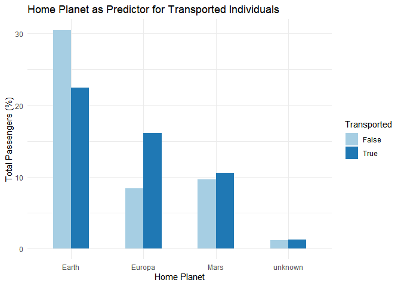

```r
train.clean %>%
  group_by(HomePlanet,
           Transported) %>%
  summarise(n = n(),
            percent = round(n/nrow(train.clean)*100,2)) %>%
  data.frame() %>%
  ggplot(aes(x = HomePlanet,
             y = percent,
             fill = Transported)) +
  geom_bar(mapping = aes(x= HomePlanet,
                         y=percent),
           stat = "identity",
           width = 0.5, position = "dodge") +
  theme_minimal() +
  scale_fill_brewer(palette = "Paired") +
  xlab("Home Planet") +
  ylab("Total Passengers (%)") +
  ggtitle("Home Planet as Predictor for Transported Individuals")
```

As illustrated from the above graph, passengers who are embarked from Earth are less likely to get transported; however, for those who embarked from Europa, they are very likely to get transported. Mars and unknown destination remain similar.

**Predictor for home planet:** whether someone from Earth or Europe.

### Cat. Predictor: CryoSleep status

Similar to the above reason, a Chi-squared test will be conducted for two categorical variables: Transported vs. CryoSleep.

```r
table(train.clean$Transported,train.clean$CryoSleep)
```

```
##
##         False True
##   False  3734  581
##   True   1824 2554
```

```r
chisq.test(train.clean$Transported,train.clean$CryoSleep,correct = FALSE)
```

```
##
##  Pearson's Chi-squared test
##
## data:  train.clean$Transported and train.clean$CryoSleep
## X-squared = 1898, df = 1, p-value <2e-16
```

**Interpretation:** The relationship between Transported passengers and CryoSleep status is less likely due to chance.

**Visualization.**

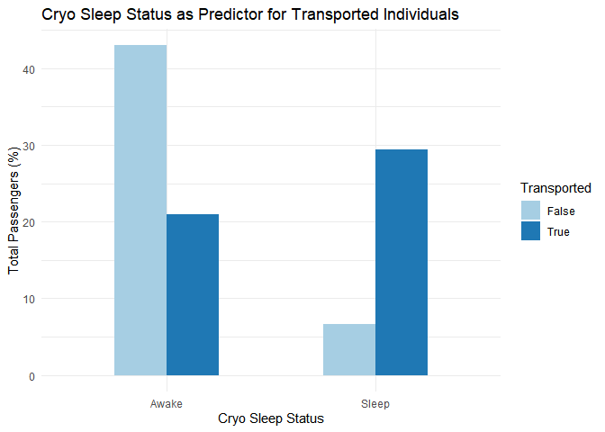

```r
train.clean %>%
  group_by(Transported,
           CryoSleep) %>%
  summarise(n = n(),
            percent = n/nrow(train.clean)*100) %>%
  data.frame() %>%
  ggplot(aes(x = CryoSleep,
             y = percent,
             fill = Transported)) +
  geom_bar(mapping = aes(x =CryoSleep,
                         y =percent),
           stat = "identity",
           width = 0.5, position = "dodge") +
  scale_x_discrete(label = c("Awake","Sleep")) +
  theme_minimal() +
  scale_fill_brewer(palette = "Paired") +
  xlab("Cryo Sleep Status") +
  ylab("Total Passengers (%)") +
  ggtitle("Cryo Sleep Status as Predictor for Transported Individuals")
```

As illustrated from the graph above, those who remain awake are less likely to be transported to an alternate dimension, while those who are in a suspended animation status are more likely to get transported.

**Predictor:** CryoSleep

### Cat. Predictor: Destination.

A Chi-square test will be conducted for Transported vs. Destination.

```r
table(train.clean$Transported,train.clean$Destination)
```

```
##
##         55 Cancri e PSO J318.5-22 TRAPPIST-1e unknown
##   False         702           395        3128      90
##   True         1098           401        2787      92
```

```r
chisq.test(train.clean$Transported,train.clean$Destination,correct = FALSE)
```

```
##
##  Pearson's Chi-squared test
##
## data:  train.clean$Transported and train.clean$Destination
## X-squared = 106, df = 3, p-value <2e-16
```

**Interpretation:** The relationship between Transported passengers and Destination is less likely due to chance.

**Visualization.**

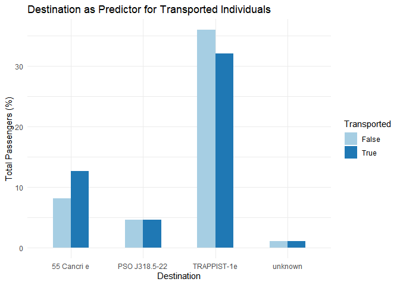

```r
train.clean %>%
  group_by(Transported,
           Destination) %>%
  summarise(n = n(),
            percent = n/nrow(train.clean)*100) %>%
  data.frame() %>%
  ggplot(aes(x = Destination,
             y = percent,
             fill = Transported)) +
  geom_bar(mapping = aes(x =Destination,
                         y =percent),stat = "identity",
           width = 0.5, position = "dodge") +
  theme_minimal() +
  scale_fill_brewer(palette = "Paired") +
  xlab("Destination") +
  ylab("Total Passengers (%)") +
  ggtitle("Destination as Predictor for Transported Individuals")
```

as illustrated above, those who were expect to arrive at 55 Cancri e is more likely to be transported. On the other hand, those whose destination is TRAPPIST-1e are less likely to be transported. PSO J318.5-22 & unknown destination are not a great predictors.

**Destination predictor:** whether a person’s destination is 55 Cancri e or TRAPPIST-1e.

### Cat. Predictor: deck

A chi-square test will be conducted for Transported vs. deck.

```r
table(train.clean$Transported,train.clean$deck)
```

```
##
##            A    B    C    D    E    F    G    T unknown
##   False  129  207  239  271  563 1565 1238    4      99
##   True   127  572  508  207  313 1229 1321    1     100
```

```r
chisq.test(train.clean$Transported,train.clean$deck,correct = FALSE)
```

```
##
##  Pearson's Chi-squared test
##
## data:  train.clean$Transported and train.clean$deck
## X-squared = 392, df = 8, p-value <2e-16
```

**Interpretation:** The relationship between Transported passengers and their cabin deck is less likely due to chance.

**Visualization.**

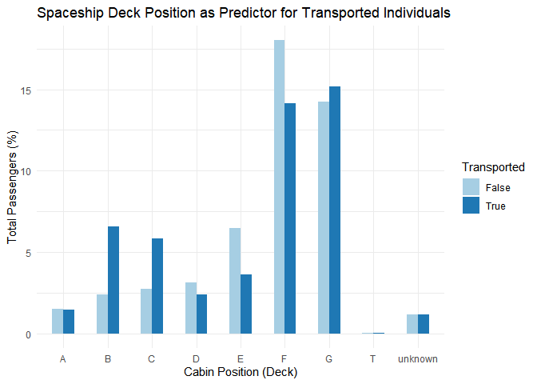

```r
train.clean %>%
  group_by(Transported,
           deck) %>%
  summarise(n = n(),
            percent = n/nrow(train.clean)*100) %>%
  data.frame() %>%
  ggplot(aes(x = deck,
             y = percent,
             fill = Transported)) +
  geom_bar(mapping = aes(x= deck,
                         y= percent),
           stat = "identity",
           width = 0.5, position = "dodge") +
  scale_x_discrete(label = c("A","B","C","D","E","F","G","T","unknown")) +
  theme_minimal()+
  scale_fill_brewer(palette = "Paired") +
  xlab("Cabin Position (Deck)") +
  ylab("Total Passengers (%)") +
  ggtitle("Spaceship Deck Position as Predictor for Transported Individuals")
```

As illustrated above, passenger who are sitting in cabin B, C, and G are more likely to be transported. Those who sit in cabin D, E, and F are less likely to get transported. Those who sit in A, T, or their cabins are unknown, are equally likely to get transported.

**Predictors:** whether someone sit in cabin B, C, D, E, F, & G.

### Cat. Predictor: side of the Ship

A Chi-squared test will be conducted for Transport vs. side variable.

```r
table(train.clean$Transported,train.clean$side)
```

```
##
##         Port Starboard unknown
##   False 2308      1908      99
##   True  1898      2380     100
```

```r
chisq.test(train.clean$Transported,train.clean$side,correct = FALSE)
```

```
##
##  Pearson's Chi-squared test
##
## data:  train.clean$Transported and train.clean$side
## X-squared = 91, df = 2, p-value <2e-16
```

**Interpretation:** The relationship between Transported passengers and the cabin location (Starboard, Port, or unknown) is less likely due to chance.

**Visualization.**

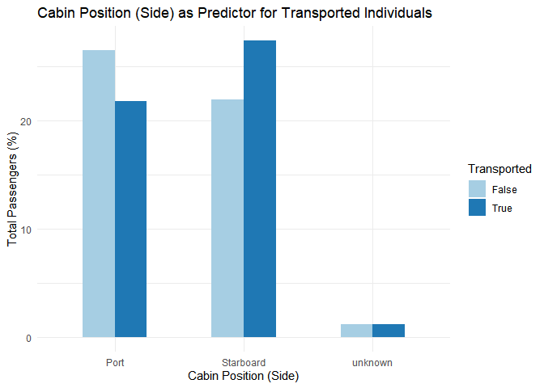

```r
train.clean %>%
  group_by(Transported,
           side) %>%
  summarise(n = n(),
            percent = n/nrow(train.clean)*100) %>%
  data.frame() %>%
  ggplot(aes(x = side,
             y = percent,
             fill = Transported)) +
  geom_bar(mapping = aes(x= side,
                         y= percent),
           stat = "identity",
           width = 0.5,
           position = "dodge") +
  scale_x_discrete(label = c("Port","Starboard","unknown")) +
  theme_minimal() +
  scale_fill_brewer(palette = "Paired") +
  xlab("Cabin Position (Side)") +
  ylab("Total Passengers (%)") +
  ggtitle("Cabin Position (Side) as Predictor for Transported Individuals")
```

As illustrated above, those who sit at the Port are less likely to be Transported, those who sit at the Starboard are more likely to be Transported. Those with unknown cabin position are equally likely to be transported.

**Predictor:** whether a person sits at the Port or Starboard.

### Cat. Predictor: VIP status

A Chi-square test will be conducted for Transported vs. VIP status.

```r
table(train.clean$Transported,train.clean$VIP)
```

```
##
##         False True unknown
##   False  4093  123      99
##   True   4198   76     104
```

```r
chisq.test(train.clean$Transported,train.clean$VIP,correct = FALSE)
```

```
##
##  Pearson's Chi-squared test
##
## data:  train.clean$Transported and train.clean$VIP
## X-squared = 12, df = 2, p-value = 0.002
```

**Interpretation:** The relationship between Transported passengers and VIP status is less likely due to chance.

**Visualization.**

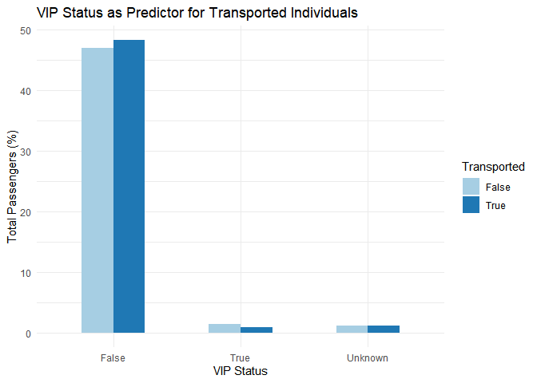

```r
train.clean %>%
  group_by(Transported,
           VIP) %>%
  summarise(n = n(),
            percent = n/nrow(train.clean)*100) %>%
  data.frame() %>%
  ggplot(aes(x = VIP,
             y = n,
             fill = Transported)) +
  geom_bar(mapping = aes(x= VIP,
                         y= percent),
           stat = "identity",
           width = 0.5, position = "dodge") +
  scale_x_discrete(label = c("False","True","Unknown")) +
  theme_minimal() +
  scale_fill_brewer(palette = "Paired") +
  xlab("VIP Status") +
  ylab("Total Passengers (%)") +
  ggtitle("VIP Status as Predictor for Transported Individuals")
```

As illustrated above, those who are not VIP are more likely to be transported. HOWEVER, the difference is very small. Even though the test is significant, I will not use VIP status as predictor.

**VIP as Predictor:** discarded.

### **Cat. Predictor: VR.use**

a Chi-squared test will be conducted for Transported vs. VR.use

```r
table(train.clean$Transported,train.clean$VR.use)
```

```
##
##           no unknown  yes
##   False 2044      90 2181
##   True  3451      98  829
```

```r
chisq.test(train.clean$Transported,train.clean$VR.use,correct = FALSE)
```

```
##
##  Pearson's Chi-squared test
##
## data:  train.clean$Transported and train.clean$VR.use
## X-squared = 967, df = 2, p-value <2e-16
```

**Interpretation:** The relationship between Transported passengers and VR.use status is less likely due to chance.

**Visualization.**

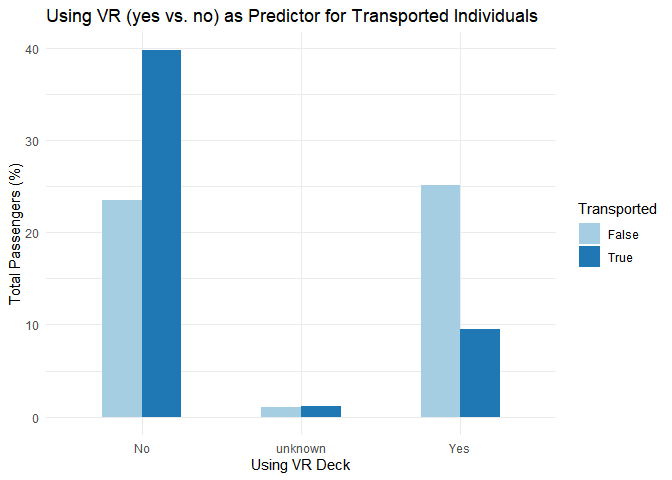

```r
train.clean %>%
  group_by(Transported,
           VR.use) %>%
  summarise(n = n(),
            percent = n/nrow(train.clean)*100) %>%
  data.frame() %>%
  ggplot(aes(x = VR.use,
             y = percent,
             fill = Transported)) +
  geom_bar(mapping = aes(x= VR.use,
                         y= percent),
           stat = "identity",
           width = 0.5,
           position = "dodge") +
  scale_x_discrete(label = c("No","unknown","Yes")) +
  theme_minimal() +
  scale_fill_brewer(palette = "Paired") +
  xlab("Using VR Deck") +
  ylab("Total Passengers (%)") +
  ggtitle("Using VR (yes vs. no) as Predictor for Transported Individuals")
```

As illustrated above, people who used the VR deck are less likely to be transported while those did not use the service is more likely to be transported. Those with unknown status are equally likely to get transported.

**VR.use as predictor:** yes vs. no

# Preparing DF for Analysis

### Predictors

From the above analyses, I decide to pick the following predictors:

- Homeplanet: Earth vs. Europa
- CryoSleep: True vs. False
- Destination: TRAPPIST-1e or 55 Cancri e
- Deck: B, C, D, E, F, G
- side: Starboard vs. Port
- VR.use: yes vs. no
- Luxury, Age, and Party Size.

**Total Predictors: 17**

### Dummy-coded Transformation

These variables will be dummy coded into 0 & 1 because we will use K-nearest neighbor, Regression Tree, and Random Forest method to build an algorithm and predict Transported.

```r
# Train.clean
train.dummy <- train.clean %>%
  mutate(Transported = ifelse(Transported == "True",1,0),
         CryoSleep = ifelse(CryoSleep == "True",1,0),
         side.starboard = ifelse(side == "Starboard",1,0),
         side.port = ifelse(side == "Port",1,0),
         Earth.home = ifelse(HomePlanet == "Earth",1,0),
         Europa.home = ifelse(HomePlanet == "Europa",1,0),
         dest.TRAP = ifelse(Destination == "TRAPPIST-1e",1,0),
         dest.55 = ifelse(Destination == "55 Cancri e",1,0),
         deck.B = ifelse(deck == "B",1,0),
         deck.C = ifelse(deck == "C",1,0),
         deck.D = ifelse(deck == "D",1,0),
         deck.E = ifelse(deck == "E",1,0),
         deck.F = ifelse(deck == "F",1,0),
         deck.G = ifelse(deck == "G",1,0),
         VR.use = ifelse(VR.use == "yes",1,0))

# Unseen.Clean
unseen.dummy <- unseen.clean %>%
  mutate(CryoSleep = ifelse(CryoSleep == "True",1,0),
         side.starboard = ifelse(side == "Starboard",1,0),
         side.port = ifelse(side == "Port",1,0),
         Earth.home = ifelse(HomePlanet == "Earth",1,0),
         Europa.home = ifelse(HomePlanet == "Europa",1,0),
         dest.TRAP = ifelse(Destination == "TRAPPIST-1e",1,0),
         dest.55 = ifelse(Destination == "55 Cancri e",1,0),
         deck.B = ifelse(deck == "B",1,0),
         deck.C = ifelse(deck == "C",1,0),
         deck.D = ifelse(deck == "D",1,0),
         deck.E = ifelse(deck == "E",1,0),
         deck.F = ifelse(deck == "F",1,0),
         deck.G = ifelse(deck == "G",1,0),
         VR.use = ifelse(VR.use == "yes",1,0))
```

### Data Frame for Analysis

The data frames for analysis will be train.dummy.1 and unseen.dummy.1

- Other variables beside Predictors will be excluded.
- As for the remaining predictors, its class will be coerced into “factor” because the syntax for kNN, rpart, and randomForest required so.

```r
# train.dummy.1
train.dummy.1 <- train.dummy %>%
  select(!c(party.identifiers,
            HomePlanet,
            deck,
            VIP,
            RoomService,
            FoodCourt,
            ShoppingMall,
            Spa,
            VRDeck,
            Name,
            side,
            Destination,
            age.group)) %>%
  mutate(CryoSleep = factor(CryoSleep),
         side.starboard = factor(side.starboard),
         side.port = factor(side.port),
         Earth.home = factor(Earth.home),
         Europa.home = factor(Europa.home),
         dest.TRAP = factor(dest.TRAP),
         dest.55 = factor(dest.55),
         deck.B = factor(deck.B),
         deck.C = factor(deck.C),
         deck.D = factor(deck.D),
         deck.E = factor(deck.E),
         deck.F = factor(deck.F),
         VR.use = factor(VR.use),
         Transported = factor(Transported))

# unseen.dummy.1
unseen.dummy.1 <- unseen.dummy %>%
  select(!c(party.identifiers,
            HomePlanet,
            deck,
            VIP,
            RoomService,
            FoodCourt,
            ShoppingMall,
            Spa,
            VRDeck,
            Name,
            side,
            Destination,
            age.group)) %>%
  mutate(CryoSleep = factor(CryoSleep),
         side.starboard = factor(side.starboard),
         side.port = factor(side.port),
         Earth.home = factor(Earth.home),
         Europa.home = factor(Europa.home),
         dest.TRAP = factor(dest.TRAP),
         dest.55 = factor(dest.55),
         deck.B = factor(deck.B),
         deck.C = factor(deck.C),
         deck.D = factor(deck.D),
         deck.E = factor(deck.E),
         deck.F = factor(deck.F),
         VR.use = factor(VR.use))
```

### Slicing Train Index

I will usen 85% of data in the train.dummy.1 to train algorithm while the remaining 15% for testing it.

- train.set: 85% of data
- test.set: 15% of data

```r
train.index <- createDataPartition(train.dummy.1$Transported,
                                   p = 0.85,
                                   times = 1,
                                   list = FALSE)

train.set <- train.dummy.1 %>% slice(train.index)
test.set <- train.dummy.1 %>% slice(-train.index)
```

# Algorithms & How to read Output

### **Definition of Sensitivity, Specificity, and Accuracy**

These are the parameters to assess how accurate the algorithm in its ability to make prediction.

- **Sensitivity is true positive**. In the context of my analysis, it refers to my algorithm’s ability to correctly predict those who would be transported.
- **Specificity is true negative.** In this context, it refers to my algorithm’s ability to correctly predict those who would NOT be transported.
- **Accuracy:** the average of sensitivity and specificity.

### Generalized Linear Model (GLM)

```r
train_glm <- train(Transported ~.,
                   method = "glm",
                   data = train.set)

y_hat_glm <- predict(train_glm,
                     test.set,
                     type = "raw")

cmglm <- confusionMatrix(y_hat_glm,
                         test.set$Transported)

data.frame(Accuracy = cmglm$overall["Accuracy"],
           Sensitivity = cmglm$byClass["Sensitivity"],
           Specificity = cmglm$byClass["Specificity"])
```

```
##          Accuracy Sensitivity Specificity
## Accuracy     0.72        0.78        0.66
```

**With the GLM method:**

- Sensitivity = .78, it means that I can correctly predict who would be transported up to 78% of the time.
- Specificity = .66, it means that I can correctly predict those would NOT be transported up to 66% of the time.
- Accuracy = .72, in overall, my predictions are correct about 72% of the time.

### K-Nearest Neighbor method (KNN

```r
control <- trainControl(method = "cv",
                        number = 10,
                        p = 0.9)

train_knn <- train(Transported ~.,
                   method = "knn",
                   data = train.set,
                   tuneGrid = data.frame(k = c(3:18)),
                   trControl = control)

fit_knn <- knn3(Transported ~ .,
                data = train.set,
                k = train_knn$bestTune$k)

y_hat_knn <- predict(fit_knn,
                     test.set,
                     type = "class")

cmknn <- confusionMatrix(y_hat_knn,
                         test.set$Transported)

data.frame(Accuracy = cmknn$overall["Accuracy"],
           Sensitivity = cmknn$byClass["Sensitivity"],
           Specificity = cmknn$byClass["Specificity"])
```

```
##          Accuracy Sensitivity Specificity
## Accuracy     0.72        0.81        0.64
```

**With the kNN method:**

- Sensitivity = .81, it means that I can correctly predict who would be transported up to 81% of the time.
- Specificity = .64, it means that I can correctly predict those would NOT be transported up to 64% of the time.
- Accuracy = .72, in overall, my predictions are correct about 72% of the time.

### Regression Tree

```r
train_rpart <- train(Transported ~ .,
                     method = "rpart",
                     data = train.set,
                     tuneGrid = data.frame(cp = seq(0,2, len = 30)))

y_hat_rpart <- predict(train_rpart,
                       test.set)

cmrpart <- confusionMatrix(y_hat_rpart,
                           test.set$Transported)

data.frame(Accuracy = cmrpart$overall["Accuracy"],
           Sensitivity = cmrpart$byClass["Sensitivity"],
           Specificity = cmrpart$byClass["Specificity"])
```

```
##          Accuracy Sensitivity Specificity
## Accuracy     0.73         0.8        0.66
```

**With the Regression Tree method:**

- Sensitivity = .80, it means that I can correctly predict who would be transported up to 80% of the time.
- Specificity = .66, it means that I can correctly predict those would NOT be transported up to 66% of the time.
- Accuracy = .73, in overall, my predictions are correct about 73% of the time.

### Random Forest

```r
train_rf <- train(Transported ~.,
                  method = "rf",
                  data = train.set,
                  tuneGrid = data.frame(mtry = seq(1:17)),
                  ntree = 500)

fit_rf <- randomForest(Transported ~.,
                       data = train.set,
                       minNode = train_rf$bestTune$mtry)

y_hat_rf <- predict(fit_rf,
                    test.set)

cmrf <- confusionMatrix(y_hat_rf,
                        test.set$Transported)

data.frame(Accuracy = cmrf$overall["Accuracy"],
           Sensitivity = cmrf$byClass["Sensitivity"],
           Specificity = cmrf$byClass["Specificity"])
```

```
##          Accuracy Sensitivity Specificity
## Accuracy     0.75         0.8        0.69
```

# Making Prediction

### Algorithms comparison table

```r
Method <- c("Generalized Linear Model",
            "K-Nearest-Neighbor",
            "Classification Tree",
            "Random Forest")

Accuracy <- c(cmglm$overall["Accuracy"],
              cmknn$overall["Accuracy"],
              cmrpart$overall["Accuracy"],
              cmrf$overall["Accuracy"])

Sensitivity <- c(cmglm$byClass["Sensitivity"],
                 cmknn$byClass["Sensitivity"],
                 cmrpart$byClass["Sensitivity"],
                 cmrf$byClass["Sensitivity"])

Specificity <- c(cmglm$byClass["Specificity"],
                 cmknn$byClass["Specificity"],
                 cmrpart$byClass["Specificity"],
                 cmrf$byClass["Specificity"])

data.frame(Method,Accuracy,Sensitivity,Specificity)
```

```
##                     Method Accuracy Sensitivity Specificity
## 1 Generalized Linear Model     0.72        0.78        0.66
## 2       K-Nearest-Neighbor     0.72        0.81        0.64
## 3      Classification Tree     0.73        0.80        0.66
## 4            Random Forest     0.75        0.80        0.69
```

### Predicting the Unseen

Per the table above, I will pick a method that yield the highest Accuracy. Hence, Random Forest algorithm is selected to make prediction.

```r
predict_unseen <- predict(fit_rf,
                          newdata = unseen.dummy.1,
                          type = "prob")

predict_unseen <- as.data.frame(predict_unseen)
colnames(predict_unseen) <- c("predict.no","predict.yes")

predict_unseen <- predict_unseen %>%
  mutate(Transported = ifelse(predict.yes > predict.no, "True","False"))

predict_unseen <- cbind(unseen$PassengerId,predict_unseen)

predict_unseen <- predict_unseen %>%
  select(!c(predict.no,
            predict.yes))
colnames(predict_unseen) <- c("PassengerId","Transported")

head(predict_unseen,20)
```

```
##    PassengerId Transported
## 1      0013_01        True
## 2      0018_01       False
## 3      0019_01        True
## 4      0021_01        True
## 5      0023_01       False
## 6      0027_01       False
## 7      0029_01        True
## 8      0032_01        True
## 9      0032_02        True
## 10     0033_01       False
## 11     0037_01       False
## 12     0040_01       False
## 13     0040_02       False
## 14     0042_01       False
## 15     0046_01       False
## 16     0046_02       False
## 17     0046_03       False
## 18     0047_01        True
## 19     0047_02       False
## 20     0047_03       False
```

# Conclusion

Using the Random Forest method, the following predictors were used to predict whether a passenger was transported to an alternate dimension: Age, Party Size, Luxury, Home Planet, Destination, using VR services, the Cabin deck and its position on the spaceship, and Cryo-Sleep status.

This algorithm yields a .75 accuracy, with .80 Sensitivity and .70 Specificity. Now let’s hope the Rescue Team can save our passengers. For those passengers that are missed by my algorithm, may the alternate dimension treat them well.